# Lesson 3

### What to Do First?

Notes:

### Pseudo-Facebook User Data

Notes:

```r
fb=read.csv("pseudo_facebook.tsv", sep = '\t')
#alterntive way of loading a tsv file
#read_delim("pseudo_facebook.tsv")
```

### Histogram of Users’ Birthdays

Notes:

```r
#install.packages('ggplot2')
library(ggplot2)
#know columns
names(fb)
```

```
##  [1] "userid"                "age"                   "dob_day"
##  [4] "dob_year"              "dob_month"             "gender"
##  [7] "tenure"                "friend_count"          "friendships_initiated"
## [10] "likes"                 "likes_received"        "mobile_likes"
## [13] "mobile_likes_received" "www_likes"             "www_likes_received"
```

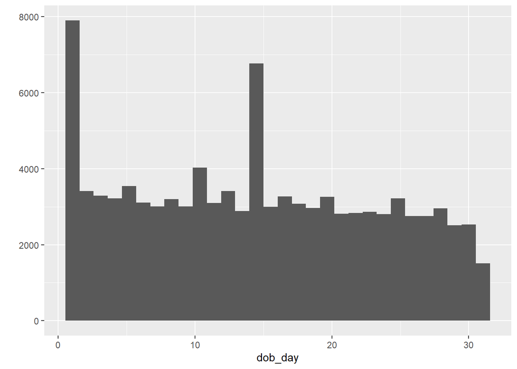

```r
qplot(data=fb, x=dob_day)
```

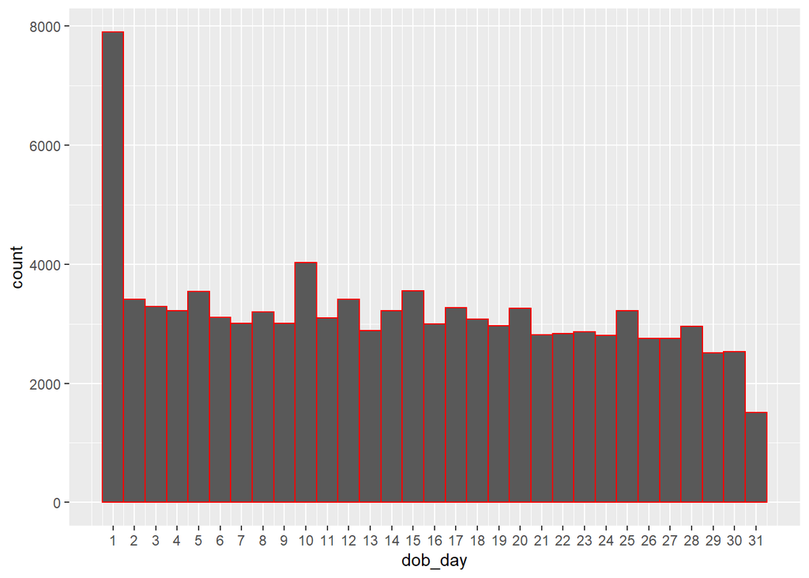

```r
#lets change bins size
ggplot(aes(x = dob_day), data = fb) +
  geom_histogram(binwidth = 1, color='red') +
   scale_x_continuous(breaks = seq(1:31))
```

#### What are some things that you notice about this histogram?

Response: the first day of histogram is a huge, while we dont have 31st in each month. so it does make sense that is shorter than the rest

### Moira’s Investigation

Notes: people perceptoions about their posts on FB. who are their audience, who is watching the post. the perception about the size of their audience.

### Estimating Your Audience Size

Notes:

#### Think about a time when you posted a specific message or shared a photo on Facebook. What was it?

Response:

#### How many of your friends do you think saw that post?

Response:

#### Think about what percent of your friends on Facebook see any posts or comments that you make in a month. What percent do you think that is?

Response:

### Perceived Audience Size

Notes:

### Faceting

Notes:

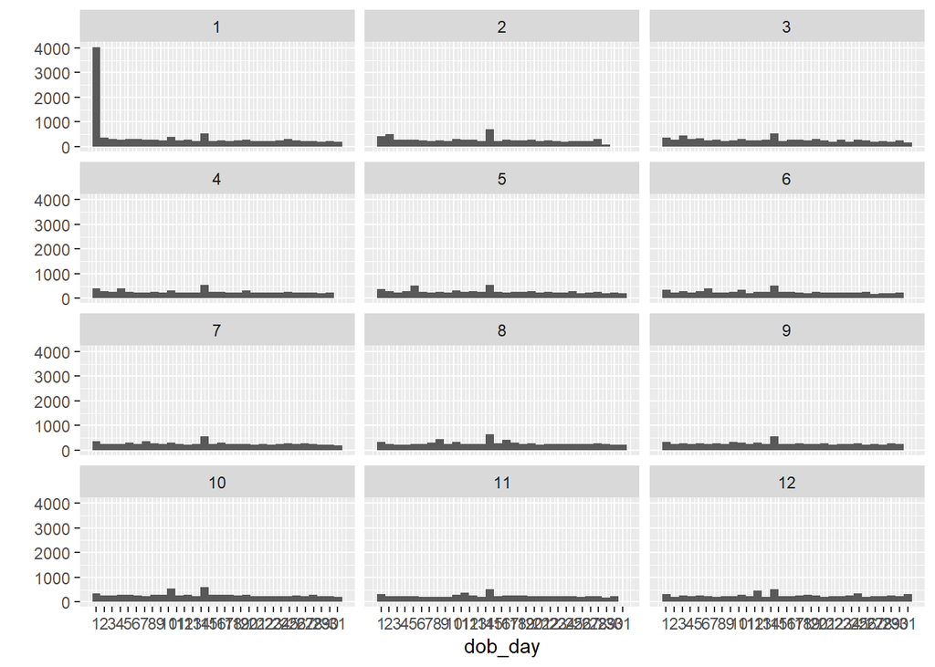

```r
qplot(data=fb , x=dob_day)+
  scale_x_continuous(breaks =1:31)+
  facet_wrap(~dob_month, ncol=3)
```

### we can write the above plot the same way as below

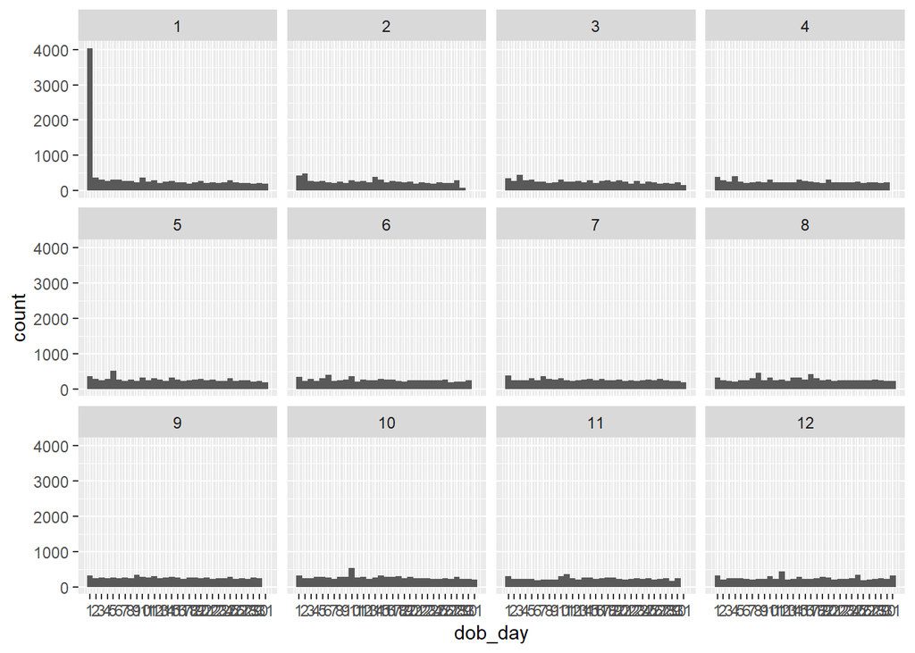

```r
ggplot(data = fb, aes(x = dob_day)) +
  geom_histogram(binwidth = 1) +
  scale_x_continuous(breaks = 1:31) +
  facet_wrap(~dob_month)
```

#### Let’s take another look at our plot. What stands out to you here?

Response: if we look at each month plot we will see some spikes in the data, but what strange enough is the spike of huge bar on first of january. It apparently looks that because of the facebook default option or users wanted to choose their privacy and went on with the first drop down option which is first of january ***

### Be Skeptical - Outliers and Anomalies

Notes:

### Moira’s Outlier

Notes: #### Which case do you think applies to Moira’s outlier? Response:

bad data of extreme case ***

### Friend Count

Notes:

#### What code would you enter to create a histogram of friend counts?

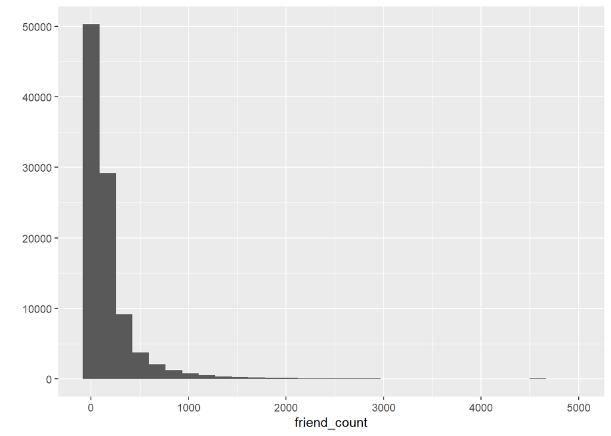

```r
qplot(data= fb, x=friend_count)
```

#### How is this plot similar to Moira’s first plot?

Response:

### Limiting the Axes

Notes: as users cant have facebook friends more than 5k and in our plot we saw not lots of people have near to 5k friends lets diminsh of xlimit to 1000 friends.

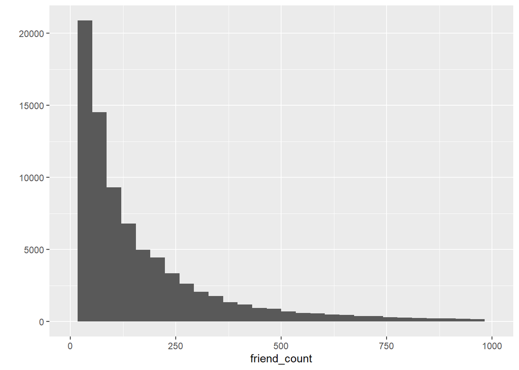

```r
qplot(data=fb, x=friend_count, xlim=c(0,1000))
```

### we can alos plot the aboce histogram as below:

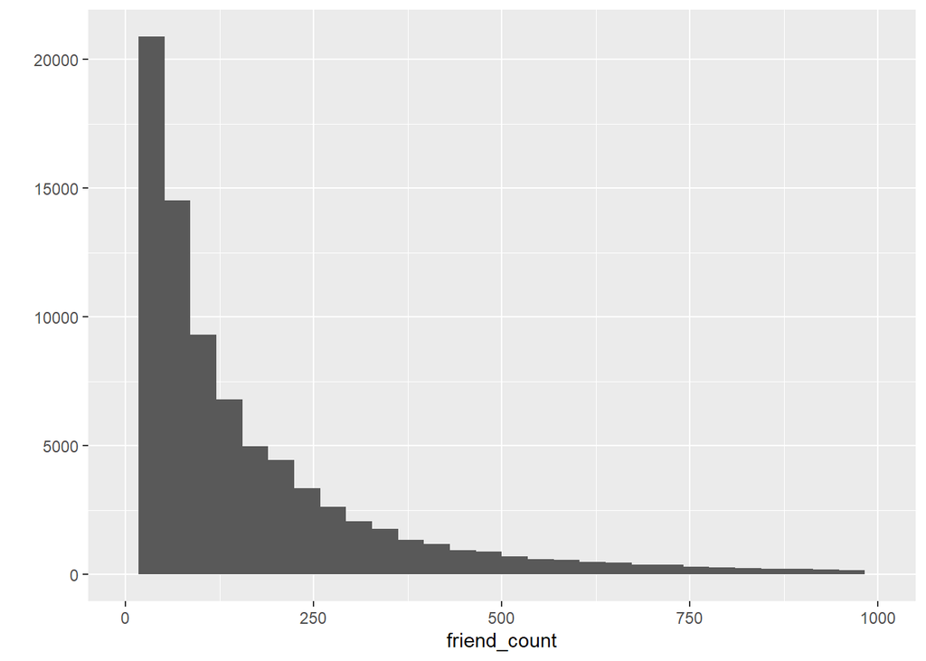

```r
qplot(data=fb, x=friend_count)+
  scale_x_continuous(limit=c(0,1000))
```

#or using ggplot

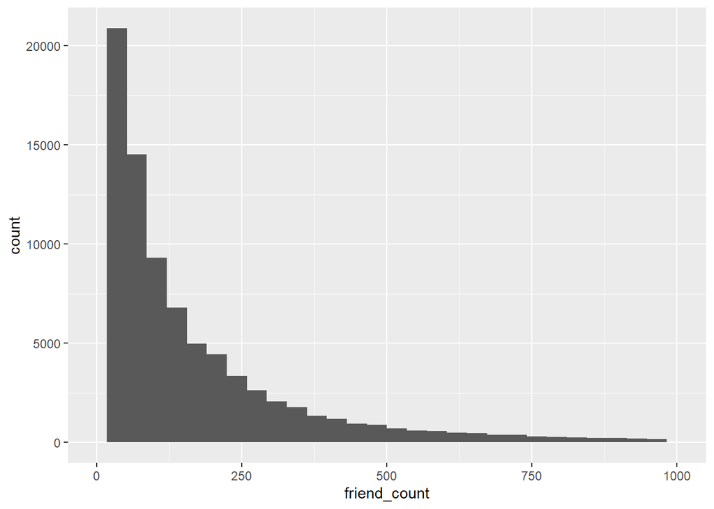

```r
ggplot(aes(x = friend_count), data = fb) +
  geom_histogram() +
  scale_x_continuous(limits = c(0, 1000))
```

### Exploring with Bin Width

Notes: binwidth= how bin u want the data should be divided by. breaks=shows the layers on x-axis ***

### Adjusting the Bin Width

Notes:

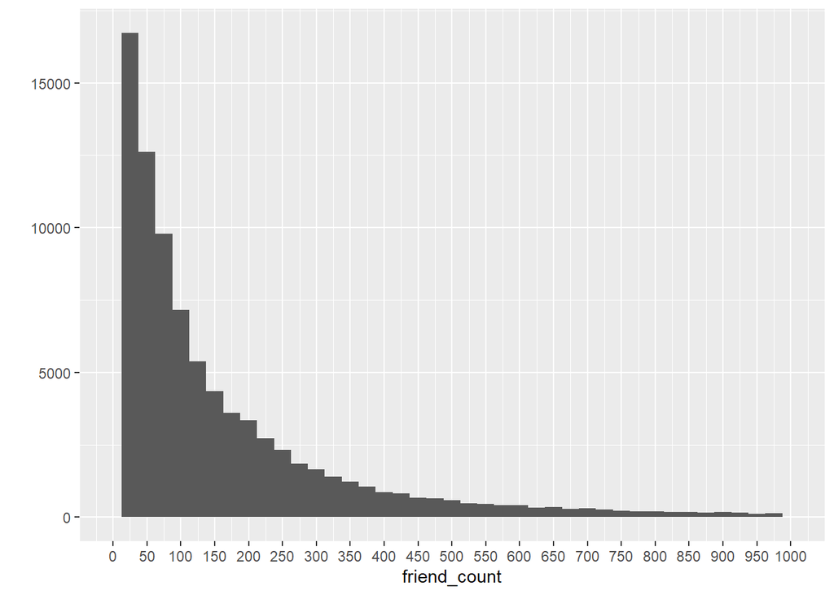

```r
qplot(data=fb, x=friend_count, binwidth= 25)+
  scale_x_continuous(limits = c(0,1000), breaks= seq(0,1000,50))
```

### Faceting Friend Count

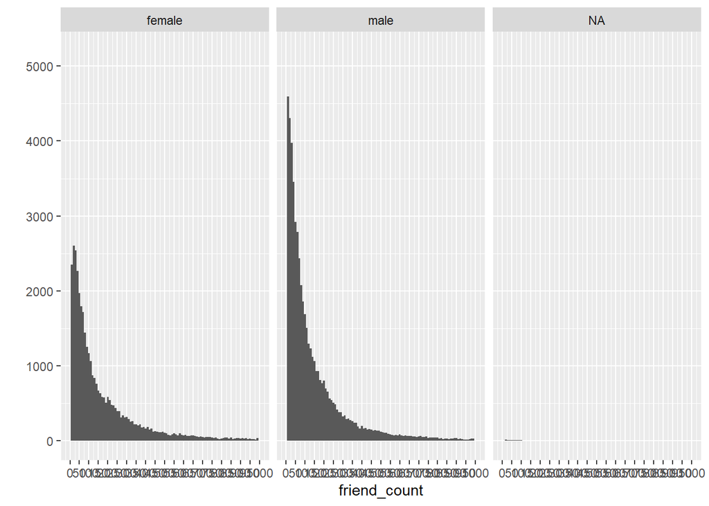

```r
# What code would you add to create a facet the histogram by gender?
# Add it to the code below.
qplot(x = friend_count, data = fb, binwidth = 10) +
  scale_x_continuous(limits = c(0, 1000),breaks = seq(0, 1000, 50))+
  facet_wrap(~gender)
```

### Omitting NA Values

Notes:

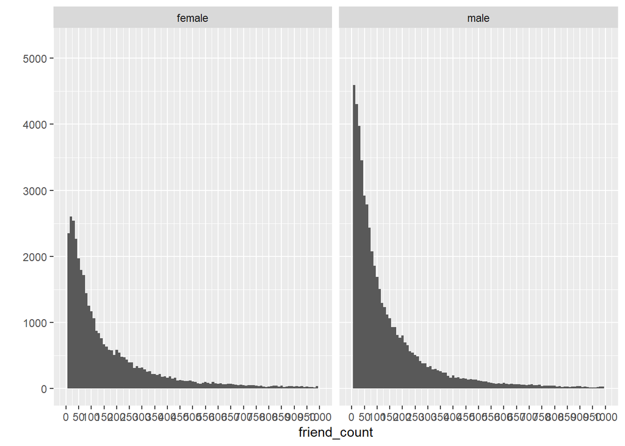

```r
qplot(x = friend_count, data = subset(fb, !is.na(gender)), binwidth = 10) +
  scale_x_continuous(limits = c(0, 1000),breaks = seq(0, 1000, 50))+
  facet_wrap(~gender)
```

#Another way of ommiting na values. but you have to be careful about it, #because it ommit all the values of df # data=na.omit(fb)

### Statistics ‘by’ Gender

Notes:

```r
table(fb$gender)
```

```
##
## female   male
##  40254  58574
```

#or

```r
by(fb$friend_count, fb$gender, summary)
```

```
## fb$gender: female
##    Min. 1st Qu.  Median    Mean 3rd Qu.    Max.
##       0      37      96     242     244    4923
## ------------------------------------------------------------
## fb$gender: male
##    Min. 1st Qu.  Median    Mean 3rd Qu.    Max.
##       0      27      74     165     182    4917
```

#### Who on average has more friends: men or women?

Response: the median and mean friend_count for women is bigger, so women have more friends than men.

#### What’s the difference between the median friend count for women and men?

Response: 96-74= 22

#### Why would the median be a better measure than the mean?

Response:

mean for friend_count is bigger than median for both male and female, it makes sense because our data is long-tailed.so these higher value out are gonna pull our mean to the right. so, the median is better measure than mean is, because its more robust statistics. few people with high number of friend_count would drag the mean upward, which is not the necessary representative of most users. what is nice that median is resistent to change since its halfway of the data points. so as long as we trust halfway value we can report our reliable location of the center of distribution. ***

### Tenure

Notes: How many days someone has been using facebook. The parameter color determines the color outline of objects in a plot. The parameter fill determines the color of the area inside objects in a plot. You might notice how the color black and the hex code color of #099DD9 (a shade of blue) are wrapped inside of I(). The I() functions stand for ‘as is’ and tells qplot to use them as colors.

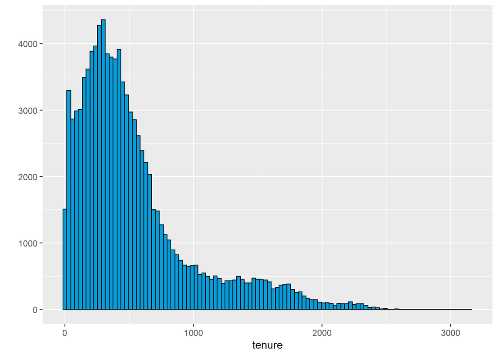

```r
qplot(x= tenure, data=fb, binwidth=30, color=I('black'), fill=I('#099DD9'))
```

#### How would you create a histogram of tenure by year?

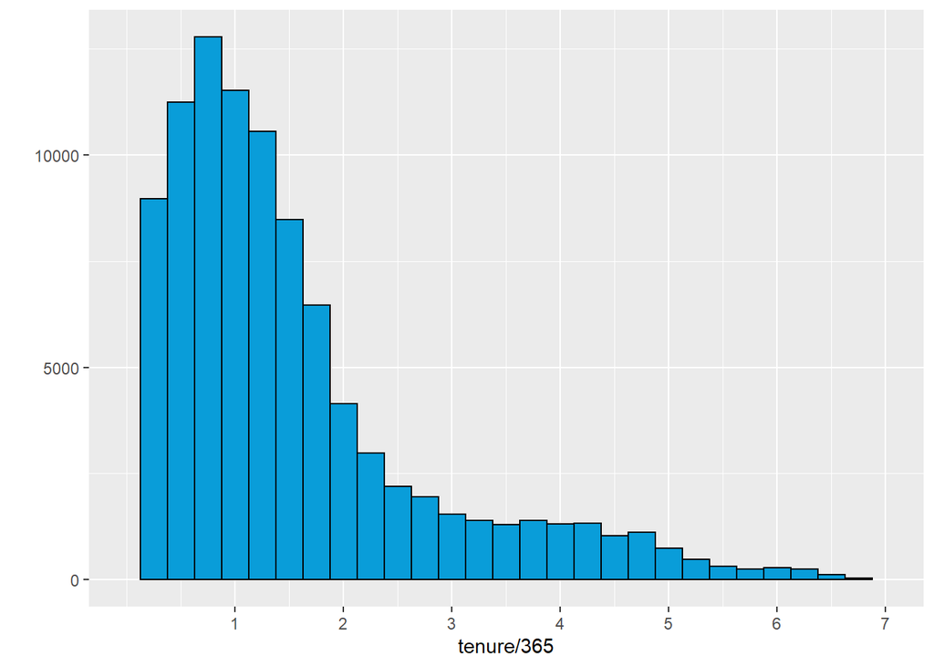

```r
qplot(x= tenure/365, data=fb, binwidth=.25, color=I('black'), fill=I('#099DD9'))+
  scale_x_continuous(breaks=seq(1,7,1),limits=c(0,7))
```

### Labeling Plots

Notes:

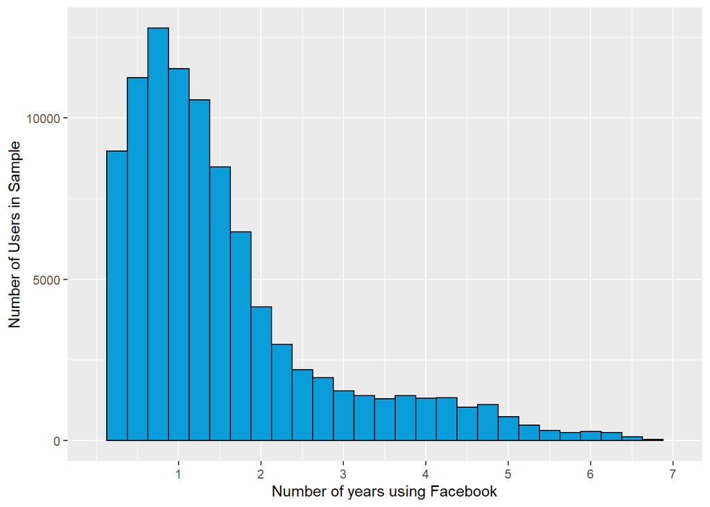

```r
qplot(x= tenure/365, data=fb, binwidth=.25,
      xlab=('Number of years using Facebook'),
      ylab=('Number of Users in Sample'),
      color=I('black'), fill=I('#099DD9'))+
  scale_x_continuous(breaks=seq(1,7,1),limits=c(0,7))
```

#equivalent

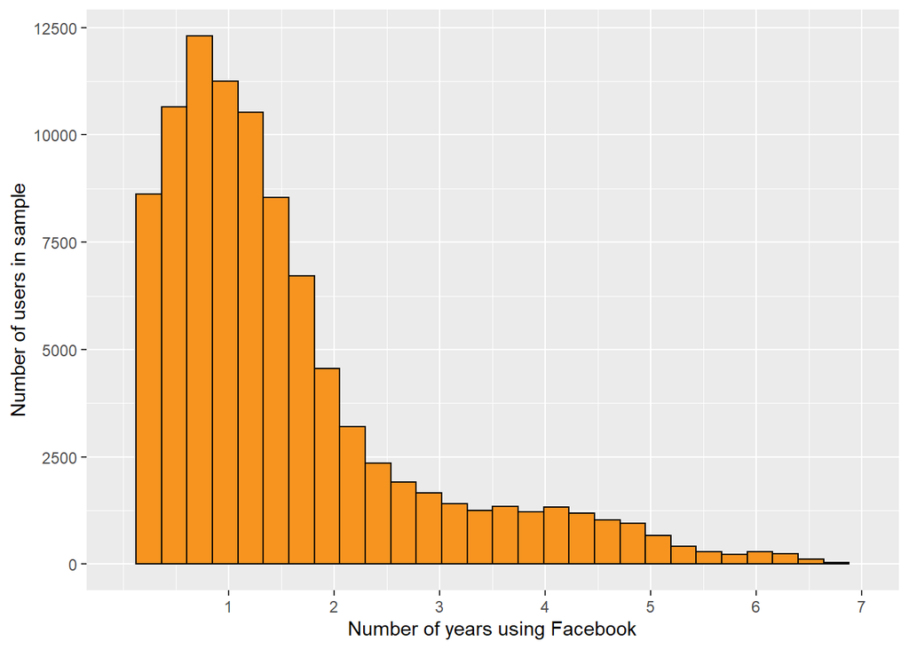

```r
ggplot(aes(x = tenure / 365), data = fb) +
  geom_histogram(color = 'black', fill = '#F79420') +
  scale_x_continuous(breaks = seq(1, 7, 1), limits = c(0, 7)) +
  xlab('Number of years using Facebook') +
  ylab('Number of users in sample')
```

### User Ages

Notes:

lets find the sumary of age

```r
summary(fb$age)
```

```
##    Min. 1st Qu.  Median    Mean 3rd Qu.    Max.
##   13.00   20.00   28.00   37.28   50.00  113.00
```

```r
names(fb)
```

```
##  [1] "userid"                "age"                   "dob_day"
##  [4] "dob_year"              "dob_month"             "gender"
##  [7] "tenure"                "friend_count"          "friendships_initiated"
## [10] "likes"                 "likes_received"        "mobile_likes"
## [13] "mobile_likes_received" "www_likes"             "www_likes_received"
```

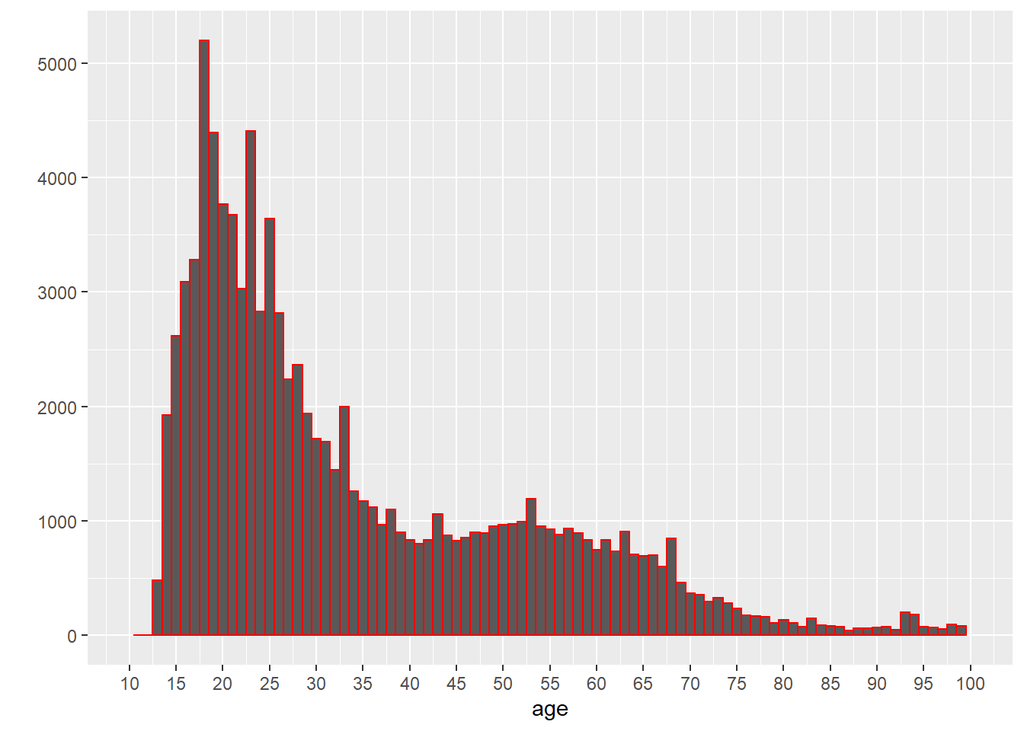

```r
qplot(data = fb, x= age, binwidth=1, color=I('red'))+
  scale_x_continuous(breaks=seq(0,113,5), limits = c(10,100))
```

#### What do you notice?

Response: we notice that most of the users age are from 15 to 40 years.

### The Spread of Memes

Notes:

### Lada’s Money Bag Meme

Notes:

### Transforming Data

Notes: some users have ten times or hundred times the median value. or some people have order of magnitude more likes, click, post and comments than any other users. in statistics we say that data is over-dispersed. we can transform the function or variable so we get rid of long tail, such as log10,2 or square root.in doing so, it helps us to see pattern more clearly

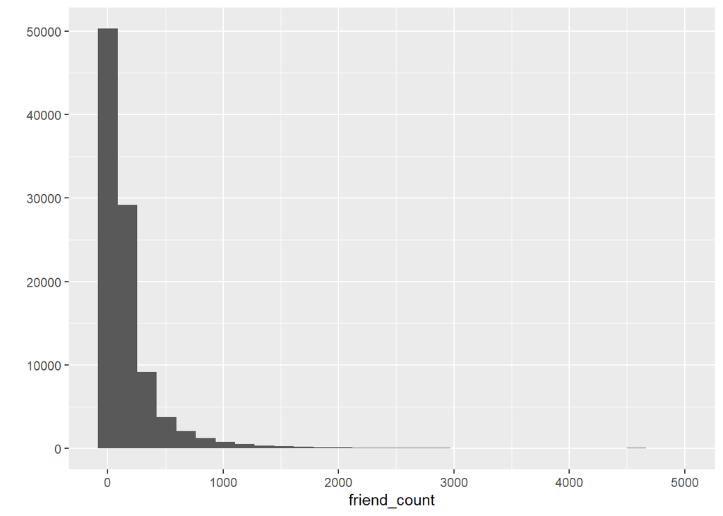

```r
qplot(data=fb, x=friend_count)
```

```r
summary(fb$friend_count)
```

```
##    Min. 1st Qu.  Median    Mean 3rd Qu.    Max.
##     0.0    31.0    82.0   196.4   206.0  4923.0
```

#lets trandform it

```r
summary(log10(fb$friend_count))
```

```
##    Min. 1st Qu.  Median    Mean 3rd Qu.    Max.
##    -Inf   1.491   1.914    -Inf   2.314   3.692
```

some of our users have friend_count of zero, so when you take log of that, it will go infinity. to get rid of infinity lets add 1 log10 has been easier as it compares friend_count on order of magnitude of 10

```r
summary(log10(fb$friend_count+1))
```

```
##    Min. 1st Qu.  Median    Mean 3rd Qu.    Max.
##   0.000   1.505   1.919   1.868   2.316   3.692
```

#another way transforming

```r
summary(sqrt(fb$friend_count))
```

```
##    Min. 1st Qu.  Median    Mean 3rd Qu.    Max.
##   0.000   5.568   9.055  11.088  14.353  70.164
```

#Plot all trasnformation

#method1 to multiple plots into one

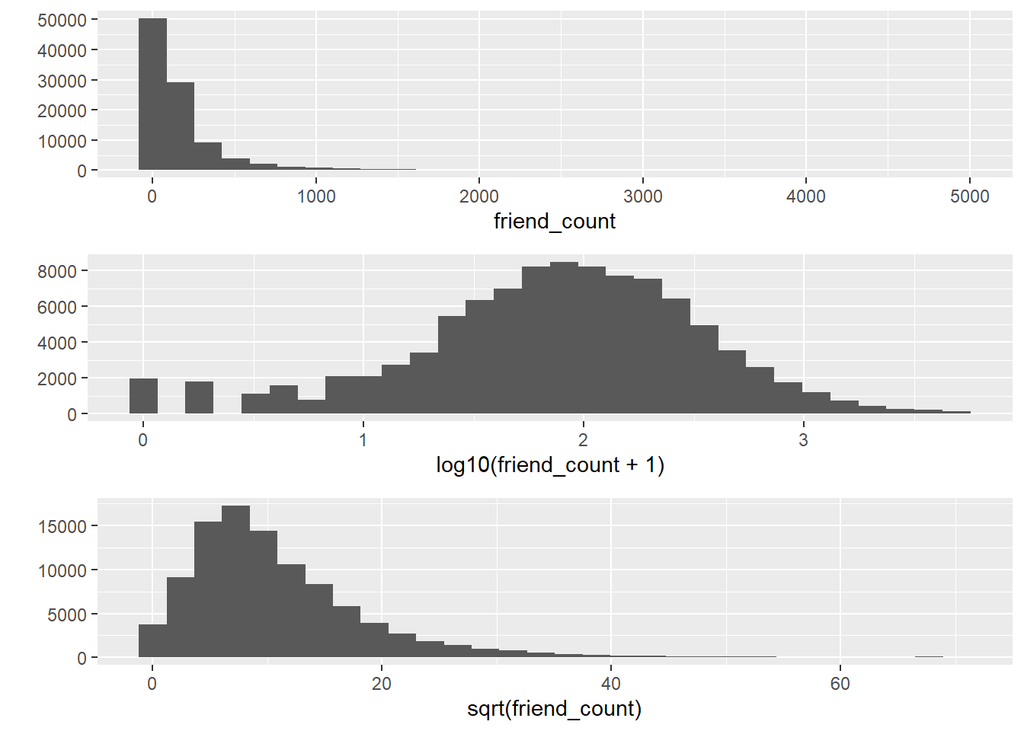

```r
library(gridExtra)
p1=qplot(data=fb, x=friend_count)
p2=qplot(data=fb, x=log10(friend_count+1))
p3=qplot(data=fb, x=sqrt(friend_count))
grid.arrange(p1,p2,p3, ncol=1)
```

#method2 usging ggplot

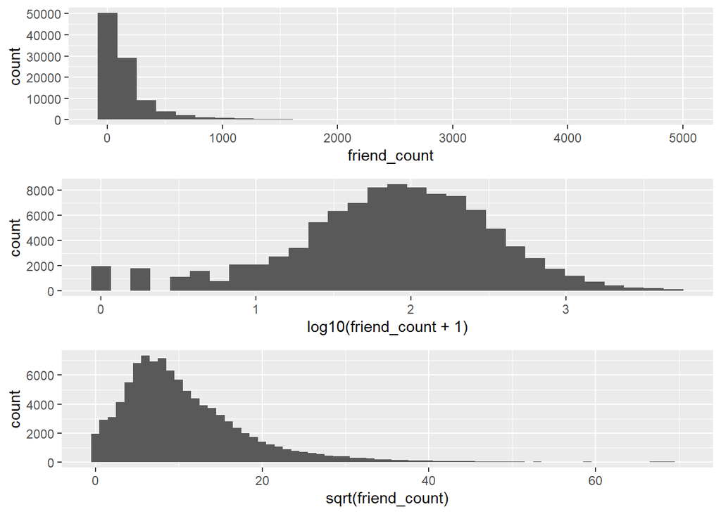

```r
library(gridExtra)
# define individual plots
p1 = ggplot(aes(x=friend_count), data = fb)+geom_histogram()
p2 = ggplot(aes(x=log10(friend_count+1)), data=fb)+geom_histogram()
p3 = ggplot(aes(x= sqrt(friend_count)), data=fb )+geom_histogram(binwidth = 1)
# arrange plots in grid
grid.arrange(p1, p2, p3, ncol=1)
```

#method3: using ggplot

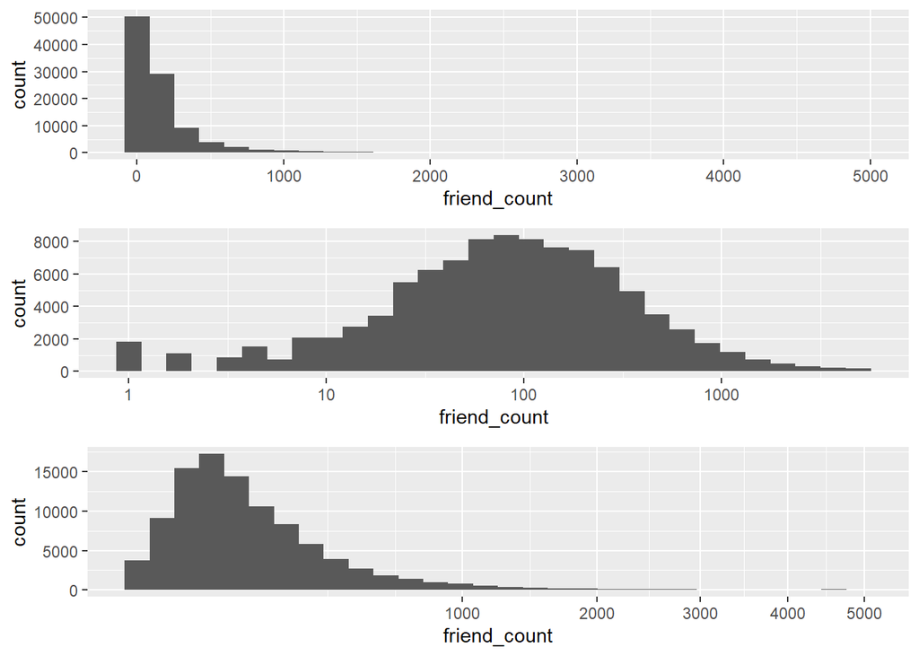

```r
p1 = ggplot(aes(x=friend_count), data = fb)+geom_histogram()

p2=p1+scale_x_log10()
p3=p1+scale_x_sqrt()
grid.arrange(p1,p2,p3, ncol=1)
```

### Add a Scaling Layer

Notes: lets compare the qplot_log10 with the scale_log10 of ggplot. the only difference we see is in the x-axis.

using:scale_x_log10 in the ggplot will label the x-axis with the actual friend_count using:log10(friend_count) will label the x-axis with log10

if we care about acutal counts, we prefere scale_x_log10

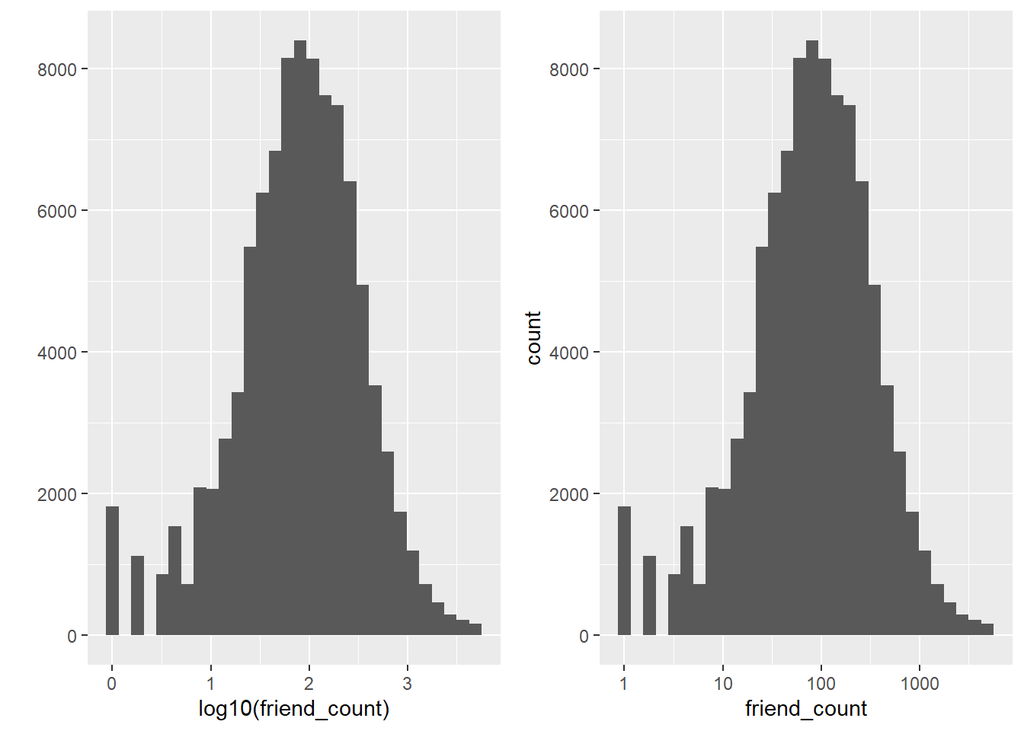

```r
qplt=qplot(data=fb, x=log10(friend_count))
gplt=ggplot(data=fb, aes(x=friend_count))+geom_histogram()+scale_x_log10()

grid.arrange(qplt,gplt, ncol=2)
```

#using scale_x_log layer with qplot:

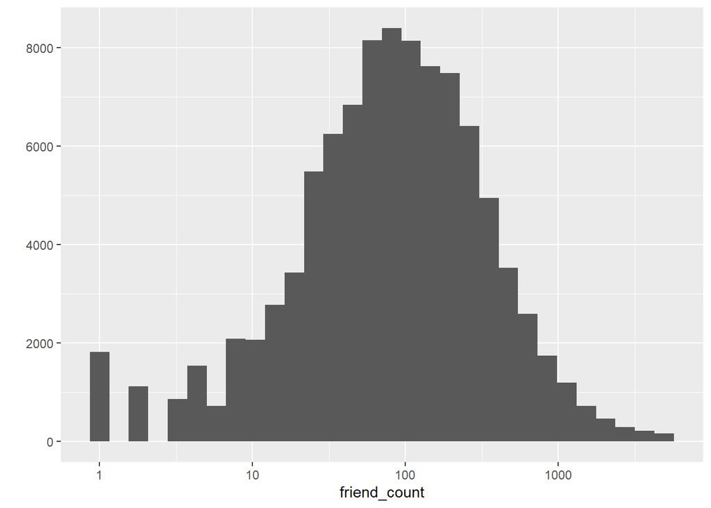

```r
qplot(x=friend_count, data=fb)+scale_x_log10()
```

*** ### Frequency Polygons frequency polygons (geom_freqpoly()) displays the counts with lines. Frequency polygons are more suitable when you want to compare the distribution across the levels of a categorical variable.

Note that the shape of the frequency polygon depends on how our bins are set up - the height of the lines are the same as the bars in individual histograms, but the lines are easier to make a comparison with since they are on the same axis.

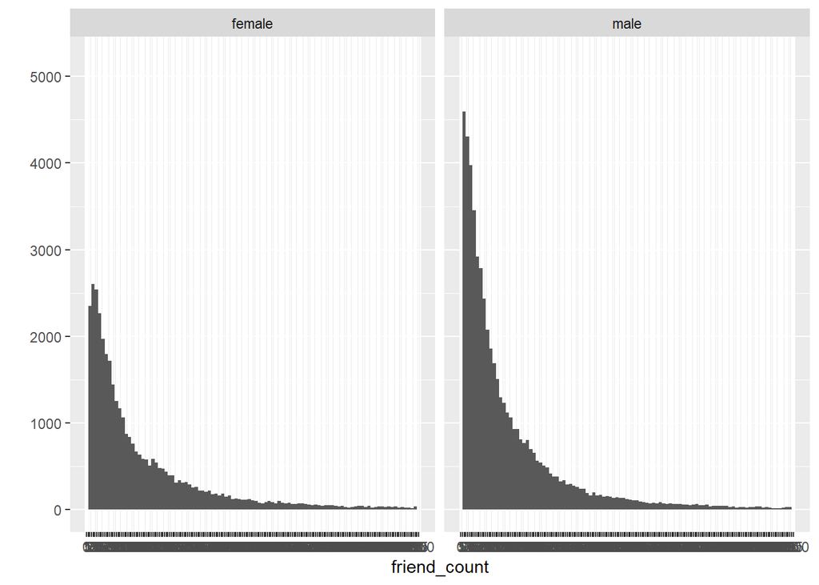

```r
qplot(data=subset(fb, !is.na(gender)), x=friend_count , binwidth=10)+
  scale_x_continuous(lim=c(0,1000), breaks=seq(0,1000,5))+
  facet_wrap(~gender)
```

###lets apply freqpolgon on the gender so we can compare both disrtribution in line

Note that sum(..count..) will sum across color, so the proportions displayed are based on total users. To plot these proportions within each group, you can try y = ..density…

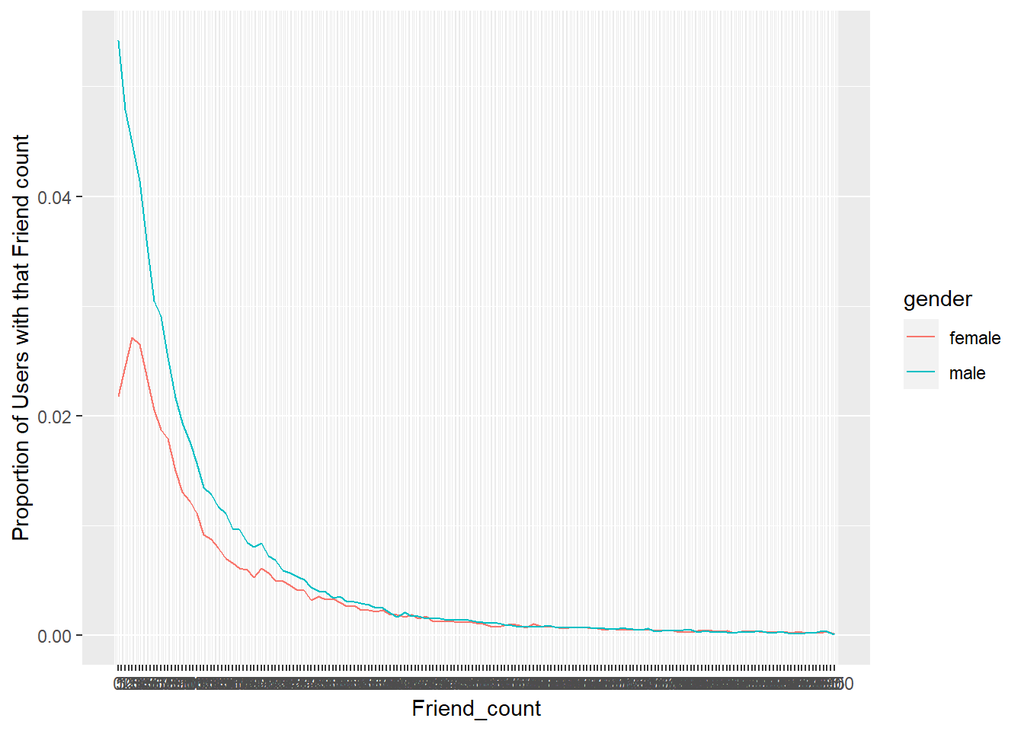

```r
qplot(data=subset(fb, !is.na(gender)), x=friend_count, y=..count../sum(..count..), binwidth=10,
      xlab='Friend_count',
      ylab='Proportion of Users with that Friend count',
      geom='freqpoly', color=gender)+
  scale_x_continuous(lim=c(0,1000), breaks=seq(0,1000,5))
```

###Lets play with the above graph so we can conclude where women takeover men.

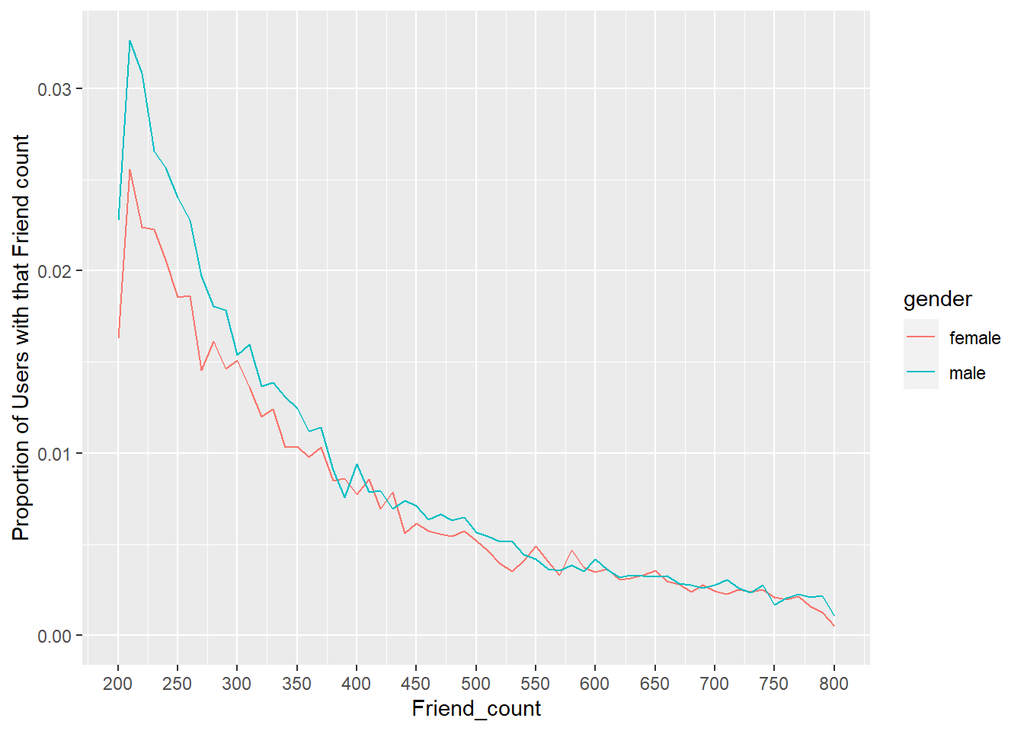

```r
qplot(data=subset(fb, !is.na(gender)), x=friend_count, y=..count../sum(..count..), binwidth=10,
      xlab='Friend_count',
      ylab='Proportion of Users with that Friend count',
      geom='freqpoly', color=gender)+
  scale_x_continuous(lim=c(200,800), breaks=seq(0,1000,50))
```

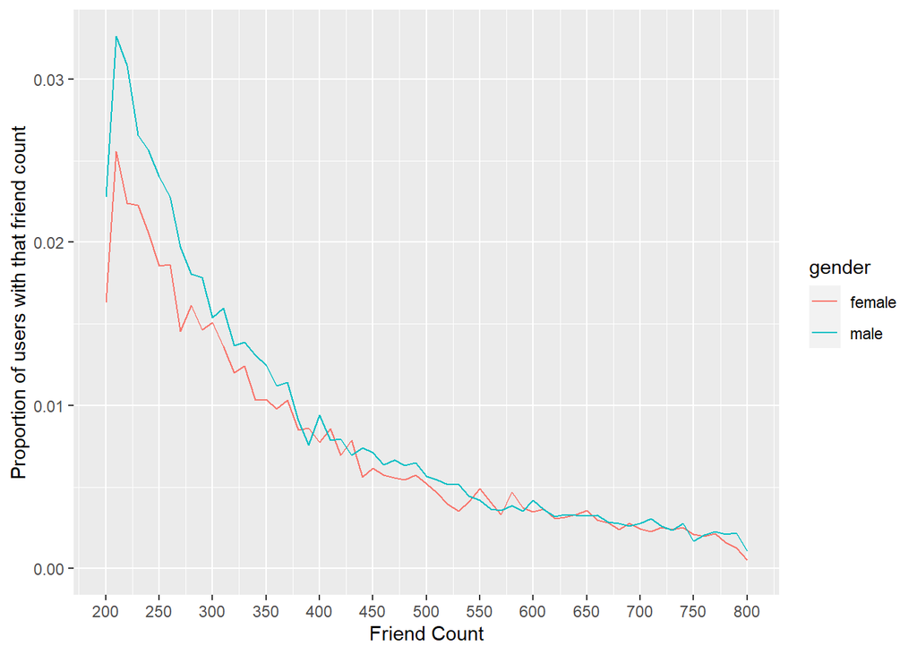

```r
ggplot(aes(x = friend_count, y = ..count../sum(..count..)),
       data = subset(fb, !is.na(gender))) +
  geom_freqpoly(aes(color = gender), binwidth=10) +
  scale_x_continuous(limits = c(200, 800), breaks = seq(0, 1000, 50)) +
  xlab('Friend Count') +
  ylab('Proportion of users with that friend count')
```

### Using Frequnecy polygon in histogram

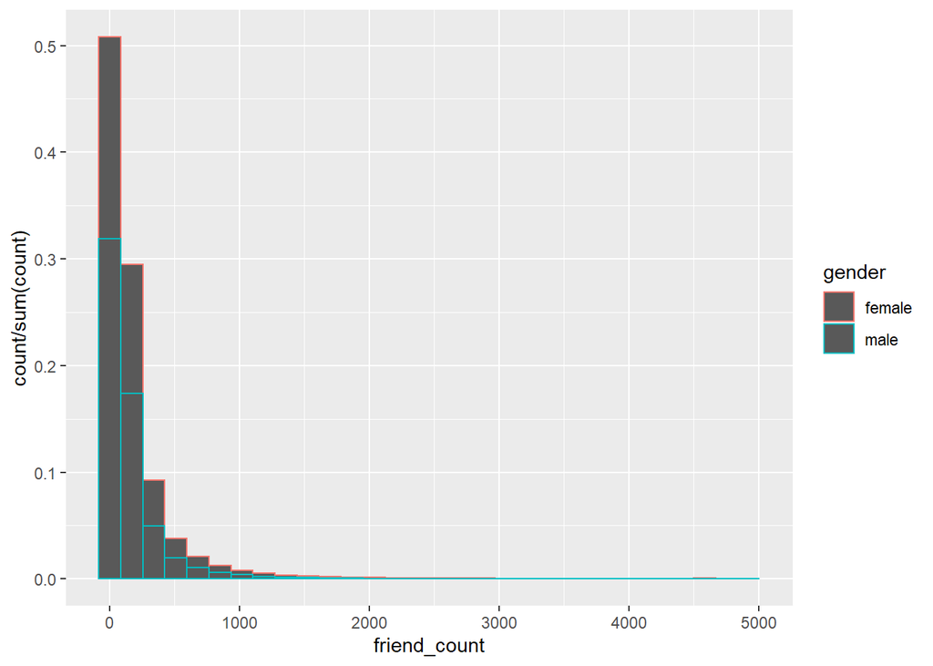

```r
ggplot(aes(x=friend_count, y=..count../sum(..count..)),
       data=subset(fb, !is.na(gender)))+
  geom_histogram(aes(color=gender))
```

geom_histogram(): counts with bar geom_freqpoly(): count with lines ***

### Likes on the Web

Notes: lets use frequency polygon and compare men and women for having higher and lower likes.

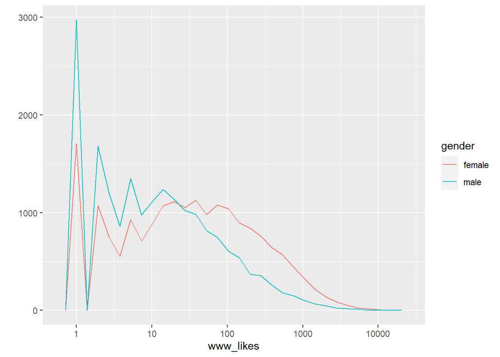

```r
qplot(data=subset(fb, !is.na(gender)) , x=www_likes, geom=('freqpoly'), color=gender)+
  scale_x_continuous()+scale_x_log10()
```

### using ggplot

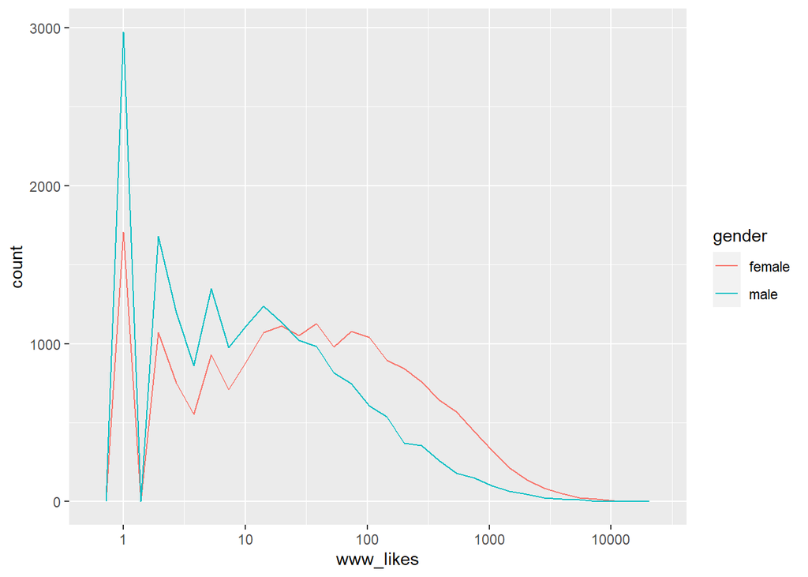

```r
ggplot(aes(x=www_likes), data=subset(fb, !is.na(gender)))+
  geom_freqpoly(aes(color=gender))+scale_x_continuous()+scale_x_log10()
```

##Likes on the web: what is the www_like count for males?

```r
library(dplyr)
fb%>% group_by(gender)%>%summarise(sum(www_likes))
```

```
## # A tibble: 3 x 2
##   gender `sum(www_likes)`
##   <chr>             <int>
## 1 female          3507665
## 2 male            1430175
## 3 <NA>               8590
```

The first question is asking how many www_likes there are in the entire data set for males.

```r
by(fb$www_likes,fb$gender,sum)
```

```
## fb$gender: female
## [1] 3507665
## ------------------------------------------------------------
## fb$gender: male
## [1] 1430175
```

### Box Plots

Notes:

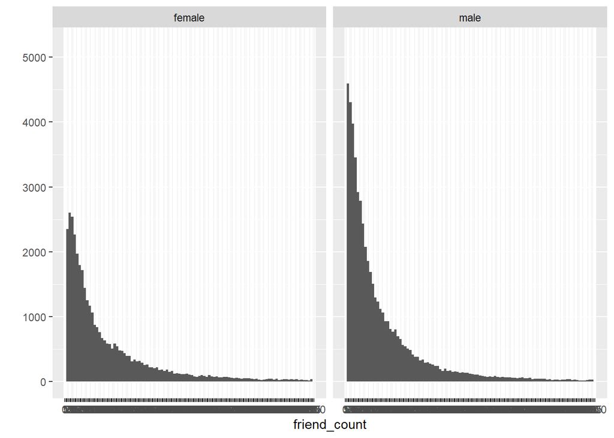

```r
qplot(data=subset(fb, !is.na(gender)), x=friend_count , binwidth=10)+
  scale_x_continuous(lim=c(0,1000), breaks=seq(0,1000,5))+
  facet_wrap(~gender)
```

lets change the above plot to more convenient plot for finding outliers. we always assign numerical(continous) variable on yaxis and categorical on x-axis in plotting boxplot.

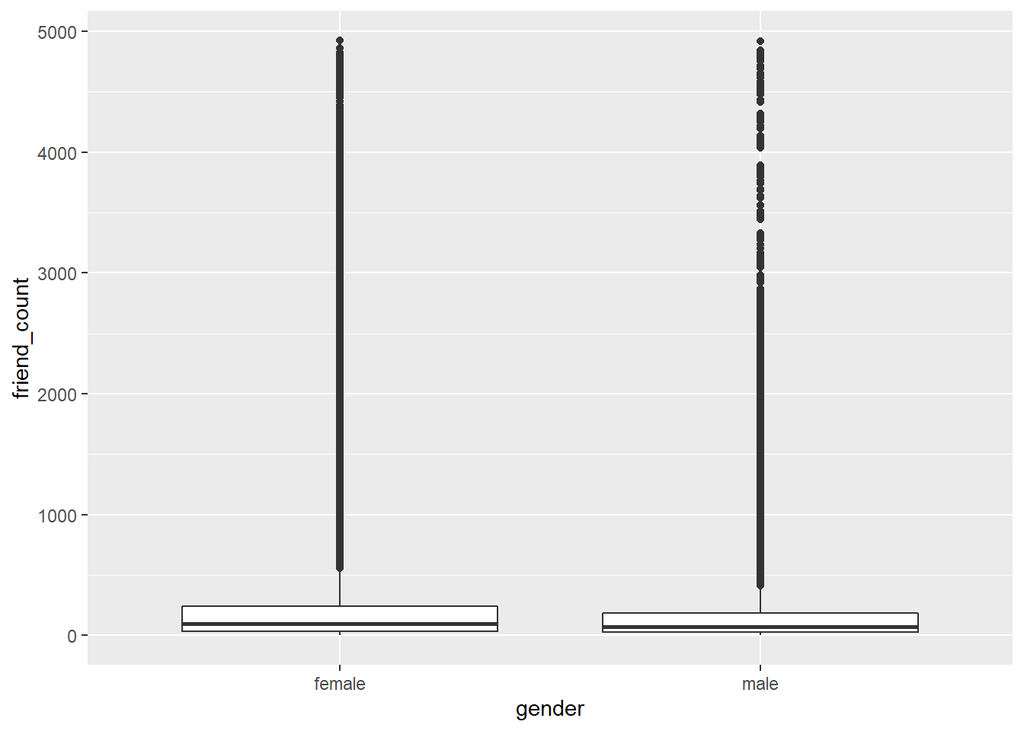

```r
qplot(geom = 'boxplot', y= friend_count, x=gender, data=subset(fb, !is.na(gender)))
```